# Identify TFs and their targets with immune functions via GSEA

By constructing GRNs, we have identified TFs with footprints on chromatin accessibility data and significant correlations with expression of target genes. Among these TFs, we further prioritized them by comparing their target size across cell types. The larger target size is, the regulation is more specific in one cell type than the rest. Now we want to know if marker TFs and their targets have any immune-related role in the regulation of each cell type.

## Perform GSEA via WebGestaltR

Three methods available on the WebGestalt server:

1. Over Representation Analysis (ORA) - Venn diagram
2. Gene Set EnrichmentAnalysis (GSEA) - enrichment plot (5) and Network Topology-based Analysis (NTA)

REF:https://academic.oup.com/nar/article/47/W1/W199/5494758?login=true

## Test enrichment for Asthma TF targets

### Gene Ontology enrichment results

Three GO categories combined: Biological Process, Cellular Component, and Molecular Function with nonredundant terms

```
[1] "Asthma TFs:"
[1] "GATA3" "TCF7"  "CEBPA" "SMAD3" "TBX21" "BACH2" "IRF1"
```

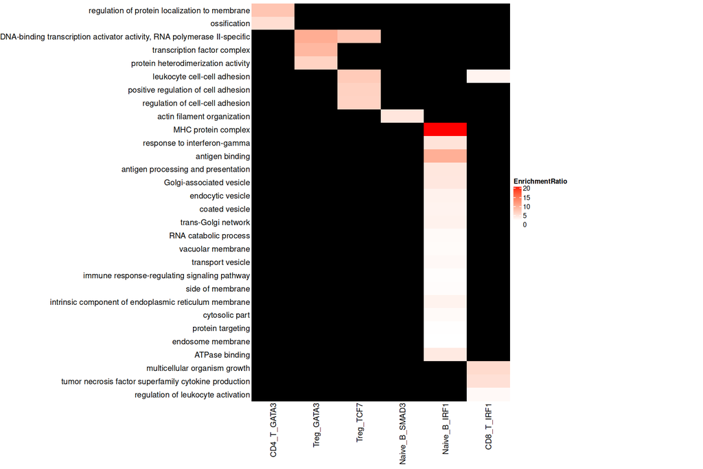

**Reduced gene sets with weighted set cover**

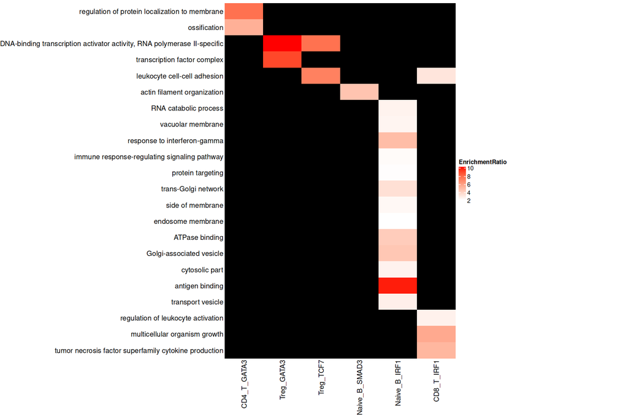

### Pathway and disease enrichment results

Three databases combined: "pathway_KEGG","disease_Disgenet", "disease_OMIM"

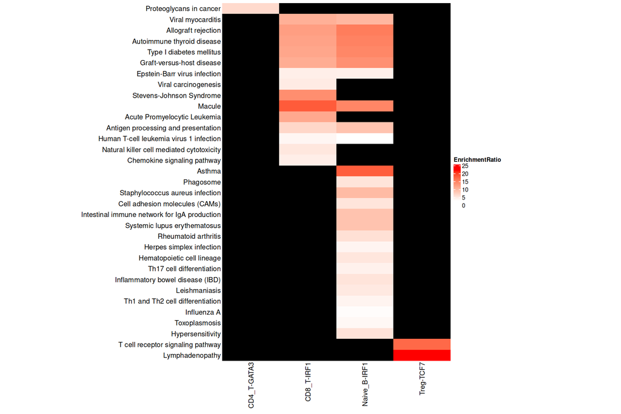

**Reduced gene sets with weighted set cover**

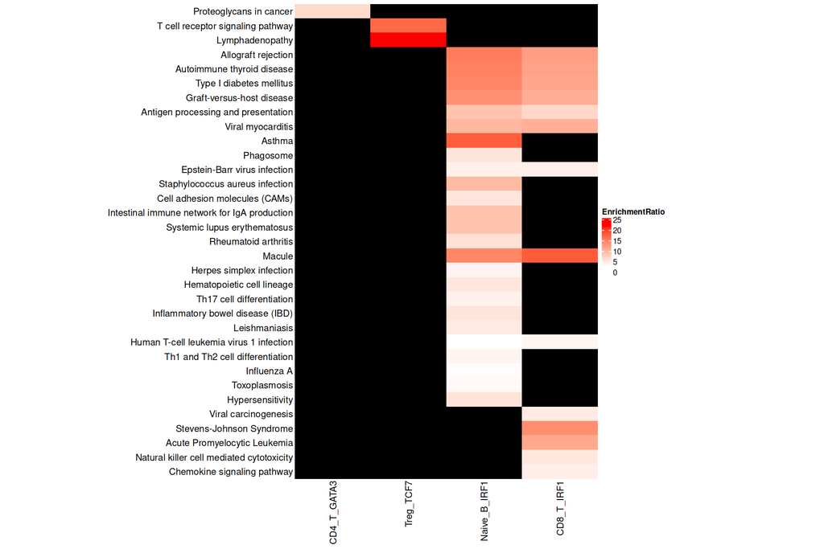

```r
out_df %>% mutate(enrichment=format(enrichmentRatio, digits=3),
       FDR=format(FDR, digits=2)) %>% filter(tf %in% c("GATA3", "TCF7", "IRF1")) %>%
select(c(tf, description, enrichment, FDR, userId))
```

A data.frame: 41 × 5

|  | tf <chr> | description <chr> | enrichment <chr> | FDR <chr> | userId <chr> |
| --- | --- | --- | --- | --- | --- |
| CD4_T.1 | GATA3 | regulation of protein localization to membrane | 7.78 | 7.0e-03 | ACSL3;CLTC;ERBB2;EZR;FYN;PTPN9;SORBS1;TFDP2;TP53BP2 |
| CD4_T.2 | GATA3 | ossification | 5.40 | 2.5e-02 | ACVR1;CLTC;DHRS3;MAPK14;MATN1;PTCH1;PTK2B;SP3;XYLT1;ZBTB16 |
| CD4_T.3 | GATA3 | Proteoglycans in cancer | 6.47 | 3.4e-02 | CD44;ERBB2;EZR;MAPK13;MAPK14;PLCG2;PTCH1;THBS1 |
| Treg.1 | GATA3 | DNA-binding transcription activator activity, RNA polymerase II-specific | 10.08 | 1.1e-04 | ATF1;ETS1;FOS;GABPA;NFYC;NR4A2;PBX2;SMAD2;SMAD3;TFCP2 |
| Treg.2 | GATA3 | transcription factor complex | 9.04 | 7.7e-04 | ATF1;ETS1;FOS;NFYC;NR4A2;PBX2;SMAD2;SMAD3;TAF1 |
| Treg.11 | TCF7 | T cell receptor signaling pathway | 17.03 | 3.9e-03 | CD28;ICOS;MAP3K8;NCK2;NFKB1;PTPRC |
| Treg.3 | TCF7 | DNA-binding transcription activator activity, RNA polymerase II-specific | 7.76 | 2.9e-02 | ELK3;HNRNPK;KLF13;KLF6;NFKB1;NFYC;PBX2 |
| Treg.4 | TCF7 | leukocyte cell-cell adhesion | 7.22 | 3.5e-02 | CD28;CD44;ICOS;IL7R;MAP3K8;NCK2;PTPRC |
| Naive_B.6 | IRF1 | Antigen processing and presentation | 8.77 | 2.1e-09 | HLA-A;HLA-B;HLA-C;HLA-DMA;HLA-DPA1;HLA-DPB1;HLA-DQA1;HLA-DQA2;HLA-DQB1;HLA-DRA;HLA-DRB1;HLA-DRB5;HLA-E;HLA-F;HSP90AB1;HSPA1A;TAPBP |
| Naive_B.25 | IRF1 | RNA catabolic process | 2.67 | 9.6e-04 | ANP32A;CASC3;CNOT1;CNOT6L;EIF4A3;HNRNPD;HNRNPR;HSPA1A;LSM2;PATL1;RNASEH2B;RPL11;RPL24;RPL38;RPL39;RPL7;RPS12;RPS18;RPS23;RPS25;RPS4X;TENT5C;TNRC6B;ZC3HAV1;ZHX2 |
| Naive_B.26 | IRF1 | vacuolar membrane | 2.59 | 1.6e-03 | ANXA6;AP3B1;ARL8B;ATP6V1D;ATP6V1G1;ATP8A1;BORCS5;CLTC;GLIPR1;HLA-DPA1;HLA-DPB1;HLA-DQA1;HLA-DQA2;HLA-DQB1;HLA-DQB2;HLA-DRA;HLA-DRB1;HLA-DRB5;HSP90AB1;LNPEP;MIOS;NEU1;RAB2A;STX7;VMP1 |
| Naive_B.9 | IRF1 | response to interferon-gamma | 4.90 | 1.2e-06 | ACTR3;CD44;GBP5;HLA-DPA1;HLA-DPB1;HLA-DQA1;HLA-DQA2;HLA-DQB1;HLA-DQB2;HLA-DRA;HLA-DRB1;HLA-DRB5;HLA-E;HLA-F;HSP90AB1;MT2A;RAB43;SP100;TRIM26;TRIM38 |
| Naive_B.31 | IRF1 | immune response-regulating signaling pathway | 2.34 | 5.0e-03 | ACTR3;ALPK1;BAG6;BTN3A1;BTN3A2;CCR7;CTSH;CYLD;HLA-DPA1;HLA-DPB1;HLA-DQA1;HLA-DQA2;HLA-DQB1;HLA-DQB2;HLA-DRA;HLA-DRB1;HLA-DRB5;HSP90AB1;HSP90B1;HSPA1A;PDE4D;PRKCE;SPG21;STAP1;TLR1;TNFAIP3 |
| Naive_B.37 | IRF1 | protein targeting | 2.22 | 1.9e-02 | AP3B1;AP4S1;DNAJC15;FIS1;ITGB1BP1;PEX1;PEX2;PHYH;RAB8B;RPL11;RPL24;RPL38;RPL39;RPL7;RPS12;RPS18;RPS23;RPS25;RPS4X;SSR1;TOMM70;UBE2D2;VPS13D;VTI1A |
| Naive_B.12 | IRF1 | Epstein-Barr virus infection | 4.28 | 2.1e-06 | CCND2;CD44;CDK6;CIR1;HLA-A;HLA-B;HLA-C;HLA-DMA;HLA-DPA1;HLA-DPB1;HLA-DQA1;HLA-DQA2;HLA-DQB1;HLA-DRA;HLA-DRB1;HLA-DRB5;HLA-E;HLA-F;MYC;NCOR2;TAPBP;TNFAIP3 |
| Naive_B.24 | IRF1 | trans-Golgi network | 3.44 | 3.5e-04 | AP4S1;APP;ARFGEF2;ATP8A1;CLTC;HLA-DPA1;HLA-DPB1;HLA-DQA1;HLA-DQA2;HLA-DQB1;HLA-DQB2;HLA-DRA;HLA-DRB1;HLA-DRB5;LAP3;RAB43;RIC1;SCAMP1;VTI1A |
| Naive_B.32 | IRF1 | side of membrane | 2.46 | 6.5e-03 | ABCA1;ATP6AP2;BORCS5;BTN3A1;BTN3A2;CCR7;CXCR5;CYLD;EPB41;HLA-DPA1;HLA-DPB1;HLA-DQA1;HLA-DQA2;HLA-DQB1;HLA-DQB2;HLA-DRA;HLA-DRB1;HLA-DRB5;HLA-E;HLA-F;PTEN;TAPBP;TGFBR2 |
| Naive_B.38 | IRF1 | endosome membrane | 2.16 | 2.8e-02 | ANXA6;ARL8B;CLTC;HLA-DPA1;HLA-DPB1;HLA-DQA1;HLA-DQA2;HLA-DQB1;HLA-DQB2;HLA-DRA;HLA-DRB1;HLA-DRB5;HLA-E;HLA-F;LDLRAD4;PMEPA1;RAB11FIP4;RAB8B;RFFL;SCAMP1;SNX27;SPG21;STX7;VTI1A |
| Naive_B.39 | IRF1 | ATPase binding | 4.26 | 4.3e-02 | ABCA1;ATP6V1G1;PDE4D;RALA;SELENOS;TOR1AIP2;USP25;ZNHIT6 |
| Naive_B.14 | IRF1 | Golgi-associated vesicle | 4.48 | 2.2e-05 | APP;CLTC;HLA-DPA1;HLA-DPB1;HLA-DQA1;HLA-DQA2;HLA-DQB1;HLA-DQB2;HLA-DRA;HLA-DRB1;HLA-DRB5;HLA-E;HLA-F;RAB8B;SPG21;TMED10;USO1;VTI1A |
| Naive_B.21 | IRF1 | Macule | 14.60 | 2.3e-04 | HLA-B;HLA-DQB1;HLA-DRB1;IKZF1;PTEN;SDHC |
| Naive_B.22 | IRF1 | Herpes simplex infection | 3.78 | 3.4e-04 | HLA-A;HLA-B;HLA-C;HLA-DMA;HLA-DPA1;HLA-DPB1;HLA-DQA1;HLA-DQA2;HLA-DQB1;HLA-DRA;HLA-DRB1;HLA-DRB5;HLA-E;HLA-F;PPP1CB;PPP1CC;SP100 |
| Naive_B.36 | IRF1 | cytosolic part | 2.68 | 1.9e-02 | BAG6;BORCS5;CASP4;CFLAR;EIF4A3;PTEN;RPL11;RPL24;RPL38;RPL39;RPL7;RPS12;RPS18;RPS23;RPS25;RPS4X;RSL24D1 |
| Naive_B.10 | IRF1 | Phagosome | 5.47 | 1.2e-06 | ATP6V1D;ATP6V1G1;HLA-A;HLA-B;HLA-C;HLA-DMA;HLA-DPA1;HLA-DPB1;HLA-DQA1;HLA-DQA2;HLA-DQB1;HLA-DRA;HLA-DRB1;HLA-DRB5;HLA-E;HLA-F;STX7;TUBB6 |
| Naive_B.11 | IRF1 | antigen binding | 9.86 | 2.0e-06 | CD48;HLA-DPA1;HLA-DPB1;HLA-DQA1;HLA-DQB1;HLA-DRA;HLA-DRB1;HLA-DRB5;HLA-E;HLA-F;TAPBP |
| Naive_B.41 | IRF1 | Influenza A | 3.03 | 4.8e-02 | HLA-DMA;HLA-DPA1;HLA-DPB1;HLA-DQA1;HLA-DQA2;HLA-DQB1;HLA-DRA;HLA-DRB1;HLA-DRB5;HSPA1A;PABPN1;RAE1 |
| Naive_B.19 | IRF1 | Rheumatoid arthritis | 5.84 | 1.2e-04 | ATP6V1D;ATP6V1G1;HLA-DMA;HLA-DPA1;HLA-DPB1;HLA-DQA1;HLA-DQA2;HLA-DQB1;HLA-DRA;HLA-DRB1;HLA-DRB5;LTB |
| Naive_B.28 | IRF1 | transport vesicle | 2.80 | 3.5e-03 | CLTC;HLA-DPA1;HLA-DPB1;HLA-DQA1;HLA-DQA2;HLA-DQB1;HLA-DQB2;HLA-DRA;HLA-DRB1;HLA-DRB5;HLA-E;HLA-F;MCTP2;RAB8B;SCAMP1;SPG21;STX7;TMED10;USO1;VTI1A |
| Naive_B.29 | IRF1 | Th17 cell differentiation | 4.13 | 3.5e-03 | HLA-DMA;HLA-DPA1;HLA-DPB1;HLA-DQA1;HLA-DQA2;HLA-DQB1;HLA-DRA;HLA-DRB1;HLA-DRB5;HSP90AB1;RARA;TGFBR2 |
| Naive_B.43 | IRF1 | Hypersensitivity | 5.52 | 5.0e-02 | CCL4;HLA-B;HLA-DQA1;HLA-DQB1;HLA-DRB1;HLA-DRB5 |
| CD8_T.18 | IRF1 | regulation of leukocyte activation | 2.73 | 4.6e-02 | CCL5;CD2;FYN;HLA-E;IKZF3;LILRB1;MSH6;NFKBIZ;PIK3CA;PIK3R1;PRELID1;RAC1;RARA;STAT5B;TMEM131L;ZFP36L1 |
| CD8_T.6 | IRF1 | Epstein-Barr virus infection | 4.36 | 9.8e-03 | CD44;HLA-A;HLA-B;HLA-C;HLA-DQB1;HLA-DRB1;HLA-E;NFKBIA;PIK3CA;PIK3R1;PSMD12;RAC1 |
| CD8_T.9 | IRF1 | multicellular organism growth | 5.67 | 1.0e-02 | MBD5;NIPBL;PIK3CA;RARA;SLC1A2;STAT5A;STAT5B;TBL1XR1;ZFP36L1 |
| CD8_T.15 | IRF1 | tumor necrosis factor superfamily cytokine production | 5.14 | 3.5e-02 | CCL3;CD2;HLA-E;LILRB1;PIK3R1;RARA;TBC1D23;TRIM27 |
| CD8_T.8 | IRF1 | Stevens-Johnson Syndrome | 13.83 | 9.8e-03 | DERL1;ELMO1;HLA-A;HLA-B;HLA-C |
| CD8_T.7 | IRF1 | Viral carcinogenesis | 4.70 | 9.8e-03 | HLA-A;HLA-B;HLA-C;HLA-E;NFKBIA;PIK3CA;PIK3R1;RAC1;SP100;STAT5A;STAT5B |
| CD8_T.11 | IRF1 | Acute Promyelocytic Leukemia | 11.36 | 2.0e-02 | CD44;NABP1;RARA;STAT5B;TBL1XR1 |
| CD8_T.12 | IRF1 | Antigen processing and presentation | 6.75 | 2.0e-02 | HLA-A;HLA-B;HLA-C;HLA-DQB1;HLA-DRB1;HLA-E;RFX5 |
| CD8_T.13 | IRF1 | Human T-cell leukemia virus 1 infection | 3.58 | 3.3e-02 | ETS2;HLA-A;HLA-B;HLA-C;HLA-DQB1;HLA-DRB1;HLA-E;NFKBIA;PIK3CA;PIK3R1;STAT5A;STAT5B |
| CD8_T.16 | IRF1 | leukocyte cell-cell adhesion | 3.23 | 3.9e-02 | CCL5;CD44;FYN;HLA-E;LILRB1;NFKBIZ;PIK3CA;PIK3R1;RAC1;RARA;SKAP1;STAT5B;TMEM131L |
| CD8_T.17 | IRF1 | Chemokine signaling pathway | 4.40 | 3.9e-02 | CCL3;CCL5;ELMO1;NFKBIA;PIK3CA;PIK3R1;RAC1;RAP1A;STAT5B |

## Test enrichment for target genes of T subset marker TFs

|  | cell_type | marker |
| --- | --- | --- |
| 1 | lungs_CD4_T | GLIS3 |
| 2 | lungs_CD4_T | TEAD1 |
| 3 | lungs_CD4_T | EOMES |
| 4 | lungs_CD4_T | LEF1 |
| 5 | lungs_CD4_T | SMAD3 |
| 6 | lungs_CD4_T | ZNF18 |
| 7 | lungs_CD4_T | E2F6 |
| 8 | lungs_CD4_T | HSF4 |
| 9 | lungs_CD4_T | BRCA1 |
| 10 | lungs_CD4_T | TCF7 |

[output cut: 30 more lines]

**Biological Process and Molecular function GO terms**

T subset marker TFs were selected based on the top 10 normalized target sizes across cell types.

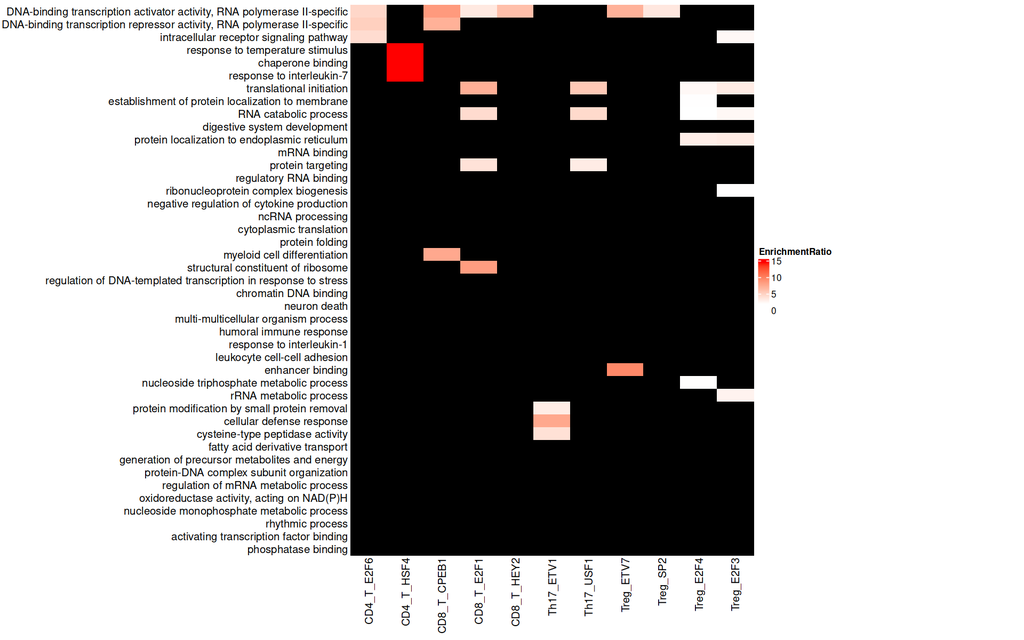

**Pathways and Diseases GO terms**

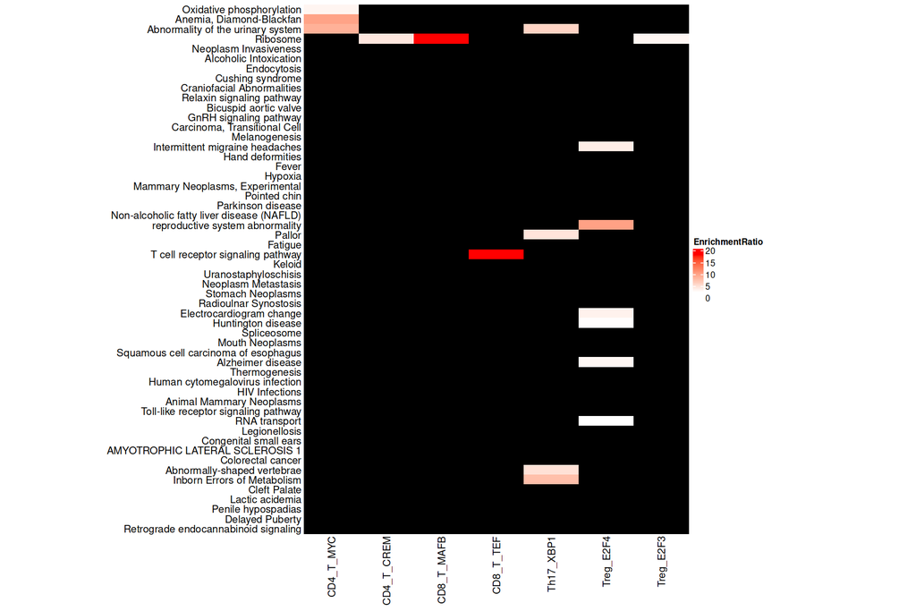